Skip to content

# Scikit-Learn Estimator Wrappers for BART

`stochtree.BARTModel` is fundamentally a Bayesian interface in which users specify a prior, provide data, sample from the posterior, and manage / inspect the resulting posterior samples.

However, the basic BART model

$$y_i \sim \mathcal{N}\left(f(X_i), \sigma^2\right)$$

involves samples of a nonparametric function $f$ which estimates the expected value of $y$ given $X$. Averaging over these draws, the posterior mean $\bar{f}$ alone may satisfy some supervised learning use cases. In order to serve this use case straightforwardly, we offer [scikit-learn-compatible estimator](https://scikit-learn.org/stable/developers/develop.html) wrappers around `BARTModel` which implement the familiar API of `sklearn` models.

For continuous outcomes, the `stochtree.StochTreeBARTRegressor` class provides `fit`, `predict` and `score` methods.

For binary outcomes (deployed via probit BART), the `stochtree.StochTreeBARTBinaryClassifier` class provides `fit`, `predict`, `predict_proba`, `decision_function`, and `score` methods.

Users can fit multi-class classifiers by wrapping a [OneVsRestClassifier](https://scikit-learn.org/stable/modules/generated/sklearn.multiclass.OneVsRestClassifier.html) around `StochTreeBARTBinaryClassifier`.

We begin by loading necessary libraries

```python
import matplotlib.pyplot as plt
import numpy as np
from sklearn.datasets import load_wine, load_breast_cancer
from sklearn.model_selection import GridSearchCV
from sklearn.multiclass import OneVsRestClassifier
from stochtree import (
  StochTreeBARTRegressor,
  StochTreeBARTBinaryClassifier,
)
```

import matplotlib.pyplot as plt import numpy as np from sklearn.datasets import load_wine, load_breast_cancer from sklearn.model_selection import GridSearchCV from sklearn.multiclass import OneVsRestClassifier from stochtree import ( StochTreeBARTRegressor, StochTreeBARTBinaryClassifier, )

Next, we seed a random number generator

```python
random_seed = 1234
rng = np.random.default_rng(random_seed)
```

random_seed = 1234 rng = np.random.default_rng(random_seed)

## BART Regression via `sklearn` Estimator

We simulate some simple regression data to demonstrate the continuous outcome use case

```python
n = 100
p = 10
X = rng.normal(size=(n, p))
y = X[:, 0] * 3 + rng.normal(size=n)
```

n = 100 p = 10 X = rng.normal(size=(n, p)) y = X[:, 0] * 3 + rng.normal(size=n)

We fit a BART regression model by initializing a `StochTreeBARTRegressor` and calling its `fit()` method.

Since `stochtree.BARTModel` is configured primarily through parameter dictionaries, any downstream parameters that we wish to set are passed through as parameter dictionaries. In this case, we only specify the random seed.

```python
reg = StochTreeBARTRegressor(general_params={"random_seed": random_seed})
reg.fit(X, y)
```

reg = StochTreeBARTRegressor(general_params={"random_seed": random_seed}) reg.fit(X, y)

```
StochTreeBARTRegressor(general_params={'random_seed': 1234})
```

Now, we can predict from this model and compare the (posterior mean) predictions to the true outcome

```python
pred = reg.predict(X)
plt.scatter(pred, y)
plt.xlabel("Predicted")
plt.ylabel("Actual")
plt.show()
```

pred = reg.predict(X) plt.scatter(pred, y) plt.xlabel("Predicted") plt.ylabel("Actual") plt.show()

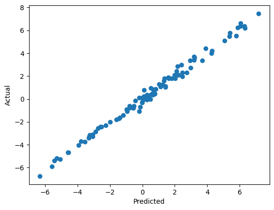

We can also test the determinism of the model by running it again with the same seed and comparing predictions to the first model

```python
reg2 = StochTreeBARTRegressor(general_params={"random_seed": random_seed})
reg2.fit(X, y)
pred2 = reg2.predict(X)
plt.scatter(pred, pred2)
plt.xlabel("First model")
plt.ylabel("Second model")
plt.show()
```

reg2 = StochTreeBARTRegressor(general_params={"random_seed": random_seed}) reg2.fit(X, y) pred2 = reg2.predict(X) plt.scatter(pred, pred2) plt.xlabel("First model") plt.ylabel("Second model") plt.show()

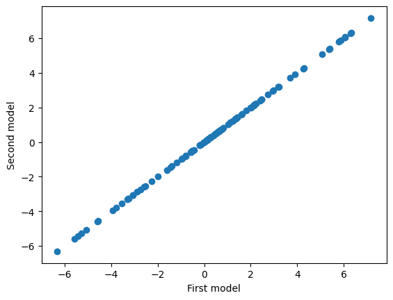

## Cross-Validating a BART Model

While the default hyperparameters of `stochtree.BARTModel` are designed to work well "out of the box," we can use posterior mean prediction error to cross-validate the model's parameters.

Below we use grid search to consider the effect of several BART parameters:

1. Number of GFR iterations (`num_gfr`)
2. Number of MCMC iterations (`num_mcmc`)
3. `num_trees`, `alpha` and `beta` for the mean forest

```python
param_grid = {
    "num_gfr": [10, 40],
    "num_mcmc": [0, 1000],
    "mean_forest_params": [
        {"num_trees": 50, "alpha": 0.95, "beta": 2.0},
        {"num_trees": 100, "alpha": 0.90, "beta": 1.5},
        {"num_trees": 200, "alpha": 0.85, "beta": 1.0},
    ],
}
grid_search = GridSearchCV(
    estimator=StochTreeBARTRegressor(),
    param_grid=param_grid,
    cv=5,
    scoring="r2",
    n_jobs=-1,
)
grid_search.fit(X, y)
```

param_grid = { "num_gfr": [10, 40], "num_mcmc": [0, 1000], "mean_forest_params": [ {"num_trees": 50, "alpha": 0.95, "beta": 2.0}, {"num_trees": 100, "alpha": 0.90, "beta": 1.5}, {"num_trees": 200, "alpha": 0.85, "beta": 1.0}, ], } grid_search = GridSearchCV( estimator=StochTreeBARTRegressor(), param_grid=param_grid, cv=5, scoring="r2", n_jobs=-1, ) grid_search.fit(X, y)

```
GridSearchCV(cv=5, estimator=StochTreeBARTRegressor(), n_jobs=-1,
             param_grid={'mean_forest_params': [{'alpha': 0.95, 'beta': 2.0,
                                                 'num_trees': 50},
                                                {'alpha': 0.9, 'beta': 1.5,
                                                 'num_trees': 100},
                                                {'alpha': 0.85, 'beta': 1.0,
                                                 'num_trees': 200}],
                         'num_gfr': [10, 40], 'num_mcmc': [0, 1000]},
             scoring='r2')
```

```python
cv_best_ind = np.argwhere(grid_search.cv_results_['rank_test_score'] == 1).item(0)
best_num_gfr = grid_search.cv_results_['param_num_gfr'][cv_best_ind].item(0)
best_num_mcmc = grid_search.cv_results_['param_num_mcmc'][cv_best_ind].item(0)
best_mean_forest_params = grid_search.cv_results_['param_mean_forest_params'][cv_best_ind]
best_num_trees = best_mean_forest_params['num_trees']
best_alpha = best_mean_forest_params['alpha']
best_beta = best_mean_forest_params['beta']
print_message = f"""
Hyperparameters chosen by grid search:
  num_gfr: {best_num_gfr}
  num_mcmc: {best_num_mcmc}
  num_trees: {best_num_trees}
  alpha: {best_alpha}
  beta: {best_beta}
"""
print(print_message)
```

cv_best_ind = np.argwhere(grid_search.cv_results_['rank_test_score'] == 1).item(0) best_num_gfr = grid_search.cv_results_['param_num_gfr'][cv_best_ind].item(0) best_num_mcmc = grid_search.cv_results_['param_num_mcmc'][cv_best_ind].item(0) best_mean_forest_params = grid_search.cv_results_['param_mean_forest_params'][cv_best_ind] best_num_trees = best_mean_forest_params['num_trees'] best_alpha = best_mean_forest_params['alpha'] best_beta = best_mean_forest_params['beta'] print_message = f""" Hyperparameters chosen by grid search: num_gfr: {best_num_gfr} num_mcmc: {best_num_mcmc} num_trees: {best_num_trees} alpha: {best_alpha} beta: {best_beta} """ print(print_message)

```
Hyperparameters chosen by grid search:
  num_gfr: 40
  num_mcmc: 0
  num_trees: 50
  alpha: 0.95
  beta: 2.0
```

## BART Classification via `sklearn` Estimator

Now, we demonstrate the same functionality with binary and categorical outcomes, which require working with the `StochTreeBARTBinaryClassifier` class (and a wrapper for multi-class outcomes).

First, we load a dataset from `sklearn` with a binary outcome.

```python
dataset = load_breast_cancer()
X = dataset.data
y = dataset.target
```

dataset = load_breast_cancer() X = dataset.data y = dataset.target

And we fit a binary classification model as follows

```python
clf = StochTreeBARTBinaryClassifier(general_params={"random_seed": random_seed})
clf.fit(X=X, y=y)
```

clf = StochTreeBARTBinaryClassifier(general_params={"random_seed": random_seed}) clf.fit(X=X, y=y)

```
StochTreeBARTBinaryClassifier(general_params={'random_seed': 1234})
```

In addition to class predictions, we can compute and visualize the predicted probability of each class via `predict_proba()`.

```python
probs = clf.predict_proba(X)
plt.hist(probs[:, 1], bins=30)
plt.show()
```

probs = clf.predict_proba(X) plt.hist(probs[:, 1], bins=30) plt.show()

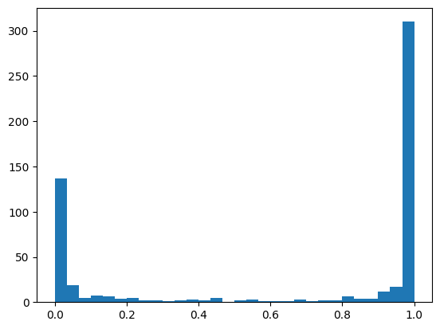

Now, we load a multi-class classification dataset from `sklearn`.

```python
dataset = load_wine()
X = dataset.data
y = dataset.target
```

dataset = load_wine() X = dataset.data y = dataset.target

And fit a multi-class classification model by wrapping a `OneVsRestClassifier` around `StochTreeBARTBinaryClassifier`.

```python
clf = OneVsRestClassifier(
    StochTreeBARTBinaryClassifier(general_params={"random_seed": random_seed})
)
clf.fit(X=X, y=y)
```

clf = OneVsRestClassifier( StochTreeBARTBinaryClassifier(general_params={"random_seed": random_seed}) ) clf.fit(X=X, y=y)

```
OneVsRestClassifier(estimator=StochTreeBARTBinaryClassifier(general_params={'random_seed': 1234}))
```

And we visualize the histogram of predicted probabilities for each outcome category.

```python
fig, (ax1, ax2, ax3) = plt.subplots(3, 1)
fig.tight_layout(pad=3.0)
probs = clf.predict_proba(X)
ax1.hist(probs[y == 0, 0], bins=30)
ax1.set_title("Predicted Probabilities for Class 0")
ax1.set_xlim(0, 1)
ax2.hist(probs[y == 1, 1], bins=30)
ax2.set_title("Predicted Probabilities for Class 1")
ax2.set_xlim(0, 1)
ax3.hist(probs[y == 2, 2], bins=30)
ax3.set_title("Predicted Probabilities for Class 2")
ax3.set_xlim(0, 1)
plt.show()
```

fig, (ax1, ax2, ax3) = plt.subplots(3, 1) fig.tight_layout(pad=3.0) probs = clf.predict_proba(X) ax1.hist(probs[y == 0, 0], bins=30) ax1.set_title("Predicted Probabilities for Class 0") ax1.set_xlim(0, 1) ax2.hist(probs[y == 1, 1], bins=30) ax2.set_title("Predicted Probabilities for Class 1") ax2.set_xlim(0, 1) ax3.hist(probs[y == 2, 2], bins=30) ax3.set_title("Predicted Probabilities for Class 2") ax3.set_xlim(0, 1) plt.show()

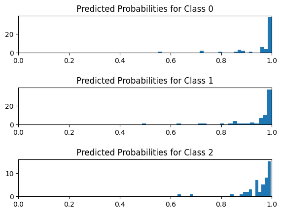